# Coursework Report

*N* removed NAs: 5

*N* removed <18: 21

**Correct typo age:** 22

*N* total clean: 142

| Group | *N* | *M*<sub>age</sub> | % green |
| --- | --- | --- | --- |
| Control | 74 | 20.66 | 49.55 |
| Experim | 68 | 20.88 | 37.75 |

| Gender | *N* | *M*<sub>age</sub> | % green |
| --- | --- | --- | --- |
| Female | 69 | 20.71 | 49.28 |
| Male | 55 | 20.80 | 38.79 |
| Other | 18 | 20.89 | 38.89 |

**Main analysis results**

**car:**  
χ<sup>2</sup>(1) = 0, *p* = 1.000

**dishwasher:**  
χ<sup>2</sup>(1) = 4.99, *p* = .025

[interactive chart not shown]

[figure not shown]

[interactive chart not shown]

# Coursework Report

Analysing Data, Spring 2020

# Methods

The investigation followed a between-subject design, in which participants who volunteered to be included were split into two condition groups; experimental and control and were primed for the experiment accordingly. Those under the experimental condition were given a story to read which had the purpose of activating their status motives, focussing on the possession of luxuries, whereas the control group was given a story of similar length which neutral status motives. This ‘group’ variable was one of the five in this investigation, the others being ID code, age, gender, product and product type.

## Participants

Summary of Participant Age and Gender in Control Story Condition

|  | female | male | other |
| --- | --- | --- | --- |
| 18 | 21 | 12 | 3 |
| 19 | 12 | 18 | 3 |
| 20 | 12 | 24 | 3 |
| 21 | 27 | 9 | 0 |
| 22 | 15 | 21 | 3 |
| 23 | 6 | 18 | 0 |
| 24 | 6 | 0 | 3 |
| 25 | 3 | 3 | 0 |

Summary of Participant Age and Gender in High-Status Story Condition

|  | female | male | other |
| --- | --- | --- | --- |
| 18 | 12 | 3 | 9 |
| 19 | 21 | 18 | 0 |
| 20 | 15 | 9 | 6 |
| 21 | 24 | 9 | 6 |
| 22 | 11 | 6 | 12 |
| 23 | 9 | 6 | 0 |
| 24 | 6 | 6 | 3 |
| 25 | 3 | 3 | 3 |
| 26 | 3 | 0 | 0 |

After the removal of data provided by participants of unethical ages, the range of ages of participants was calulated to be 8, with all participants being aged between 18 and 26. The mean of participants’ ages was 20.76 and the stanard deviation calculated at 1.96, as summarised below.

Age Summary

| mean | sd | min | max |
| --- | --- | --- | --- |
| 20.76 | 1.96 | 18 | 26 |

## Design

The aim of this study is to to answer the question of why people buy green, similarly to a related study conducted by Griskevicis and Tybur which was based on the hypothesis that participants participants who’s status motives had previously been primed would be more inclined to purchase ‘green’ or pro-environmental products, as having the means to sacrifice quality for environmental is a social signal of wealth. This experiment aims to test whether the findings and conclusions in the original paper by Griskevicis and Tybur are generalizable and reproducible when the experiment is redone. The investigation followed a between-subject design with two condition groups; experimental and control. The design contained a numerical variable of age and four categorical variables of ID code, gender, group, product and product type. The product variable contained three levels, which corresponded to the three products of which participants chose either the luxury or the green option. These levels were; car, dishwasher and cleaner. The variable of product type contained the two levels corresponding to the equally priced variations of each product available, which was the luxury option and the green option.

# Results

Contrary to what was expected, activation of status motives appeared to negatively impact how many people decided to make the choice of buying green rather than luxury. The general pattern showed that when this status motive was primed with the high-status story, the choice of luxury products was more popular than that of the green alternative, thus meaning that those within the control story group tended to favour green products more than those in the high-status story condition. This was most notable for dishwasher choices, where a majority of participants within the control group chose the green option [41] rather than the luxury [33] however, in the high-status story group, the results were drastically different with a luxury to green product choice split of 44:24. This suggested a significant correlation between test condition and product type choice, χ2 = 4.99, p = 0.03.

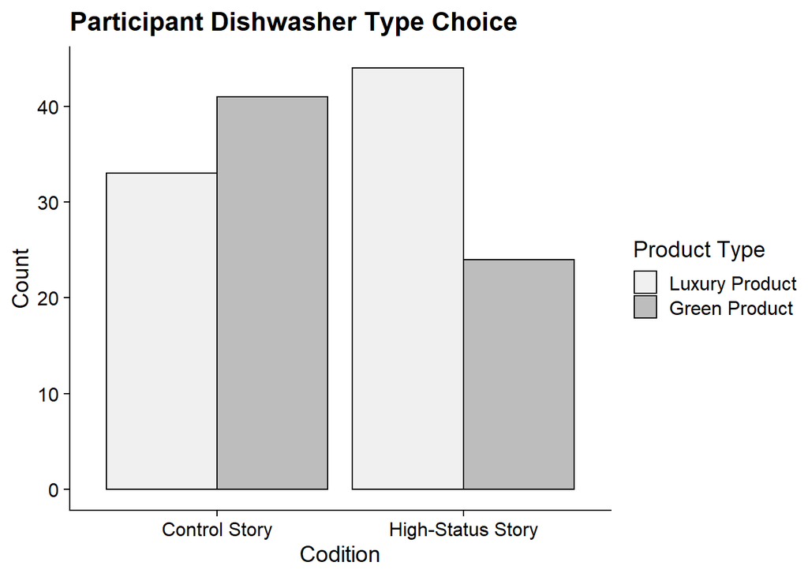

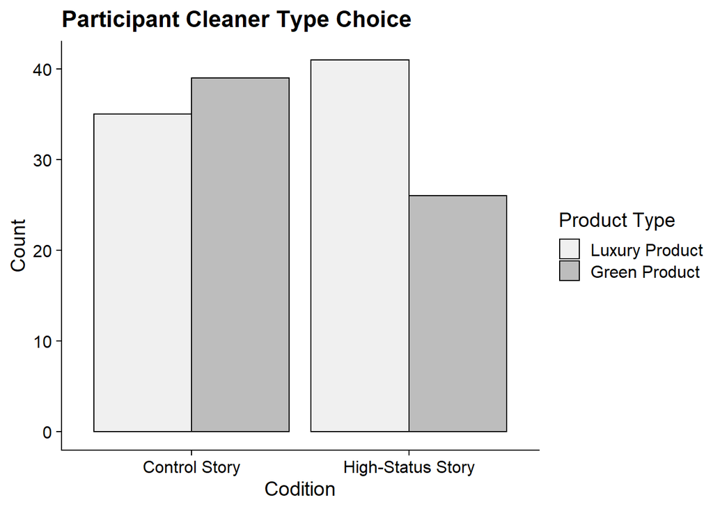

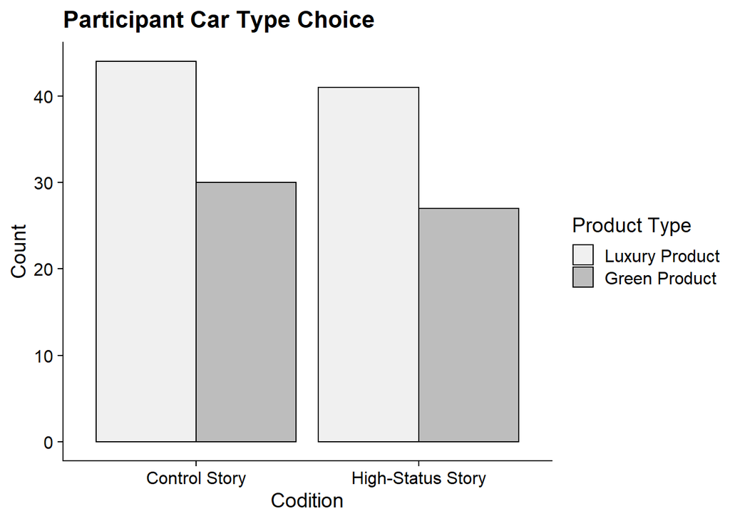

# Discussion

The results analysed above show inconsistency throughout different products and therefore do not allow for a conclusive answer to the research question of why people buy green. However, they do let us determine that the hypothesis of buying pro-environmental products being related to status motives is not generally true, though it can be applicable to certain scenarios, as was true for dishwasher choices. These results contrast those of the original study conducted by Griskevicius and Tybur and suggest they are not necessarily replicated when the experiment is repeated. In that original study, it was found that when status motives were primed through reading a high-status story, frequency of green product choice was drastically higher than in control groups for all three products tested. While their results supported the hypothesis, the results of the current study did not. Through analysis of responses of both condition groups to which dishwasher they preferred suggest that the null hypothesis can be rejected, this is only true for this product as determined by statistical test analysis.

```
##
##  Pearson's Chi-squared test with Yates' continuity correction
##
## data:  .
## X-squared = 4.9926, df = 1, p-value = 0.02546
```

The fact that both the remaining products did not allow for such conclusions to be drawn suggests that human motivation to buy green is highly dependent on the circumstances and the product in question, as in some instances, as in the case of the cleaner, luxury quality is preferred over the environmental impact of buying pro-environmental products,

```
##
##  Pearson's Chi-squared test with Yates' continuity correction
##
## data:  .
## X-squared = 2.2022, df = 1, p-value = 0.1378
```

Furthermore, the lack of impact of story condition on preference of product type in the category of cars compared to slight changes in preference of the other products may lend insight into how much people are actually willing to sacrifice in quality and style when the monetary value of the product in question is high. This can be said due to the fact that the recorded responses of participants were very close to the expected results from a chi-squared test.

```
##
##  Pearson's Chi-squared test with Yates' continuity correction
##
## data:  .
## X-squared = 0.00000000000000000000000000000088732, df = 1, p-value = 1
```

Moreover, the results of the current study further contrast various other studies which investigated human motivation behind buying. A study published in 2010 led by Sundie et al., looked into why many people reject products available at lower prices and are willing to opt for more expensive alternatives despite discrepancies between price and quality. In the study it was suggested that “self-presentational concerns override desires to obtain goods at bargain prices” (Sundie et al., 2010) following the concept of conspicuous consumption. This theory that people purchase expensive products for the sake of the social signal of owning said expensive products relates to the original study the current investigation is based on as both suggest that people sacrifice in product quality – whether that be buying expensive cars which do not perform up to their value or green products that do not perform as well as luxuries – to signal to society that they have the means to either own these high status products or that they have the means to care for the environment.

Though precautions were taken to ensure accuracy within this experiment, weaknesses did occur within the study along with its strengths. The study featured a noteable sample size of 163, which allowed for some accurate statistical analysis, however there were some discrepancies in number of responses per product leading to initial errors within this analysis. It could however have benefited from an even larger sample size to arrive at more reliable results. Furthermore, the range of participant age within the study was rather limited, only featuring a range of 8 making it unclear whether the findings from the results can be extrapolated to older demographics or are only typical for these young adult ages. This may have a an impact on the validity of the data as different age demographics place different emphasis on social status. Lastly, further investigation into how people of different cultural and educational backgrounds responded to the experiment may have led to interesting conclusions on how the answer to the research question could potentially vary between people of contrasting cultural backgrounds and levels of education and upbringing.

The discrepancy between results of the current study and those of related studies further reiterates a notion that is popular in the field of psychology; the notion that human motivation is a complex concept which cannot be linearly mapped. It highlights that motivation is very case specific and unique to indivuduals based off of their morals and values and can therefore not be generalized as this assumes that this can be done to something so individual as human behaviour.

# References

Sundie, Jill, and Douglas T. Kenrick. “Peacocks, Porsches and Thorstein Veblen: Conspicuous Consumption as Sexual Signaling.” *PsycEXTRA Dataset, 2010, doi:10.1037/e621442012-131.*

Griskevicius, Vladas, et al. “Going Green to Be Seen: Status, Reputation, and Conspicuous Conservation.” *PsycEXTRA Dataset, 2010, doi:10.1037/e621072012-217.*